# About the data set

Dream Housing Finance company deals in all kinds of home loans. They have presence across all urban and semi urban and rural areas. Customer first applies for home loan and after that company validates the custeomer eligibility for loan company wants to automate the loan eligibility process(real time) based on customer detail provided while filling online application form. These details are Gender,Marital Status, Education, Number of Dependents, Income,LoanAmount,Credit History and others.To automate this process,they have provided a dataset to identify the customers segments tat are eligible for loan amount so that they can specifically target these customers.

# Data Id

# Columns Description 1 Loan_ID A uniques loan ID 2 Gender Male/Female 3 Married Married(Yes)/Not married(No) 4 Dependents Number of persons depending on the client 5 Education Applicant Education (Graduate/Undergraduate) 6 Self_Employed Self emplyored(Yes/No) 7 ApplicantIncome Applicant income 8 CoapplicantIncome Coapplicant income 9 LoanAmount Loan amount in thousands 10 Loan_Amount_Term Term of lean in months 11 Credit_History Credit history meets guidelines 12 Property_Area Urban/Semi and Rural 13 Loan_Status Loan approved (Y/N) It is a classification problem where we have to predict whether a loan would be approved or not. In a classification problem, we have to predict discrete values based on a given set of independent variable(s). Evaluation Metric is accuracy i.e. percentage of loan approval you correctly predict.

# The main objective for this dataset:

Using machine learning techniques to predict loan payments.

# Libraries

```python
import numpy as np                      # linear algebra
import pandas as pd                     # data processing and Manipulation
import matplotlib.pyplot as plt         # Data visualization
import seaborn as sns                   # Data visualization
from sklearn import svm
```

# Reading the data

```python
df = pd.read_csv("C:\\Users\\admin\\Documents\\loan.data.csv")
```

# exploratory Data Analysis

```python
df.head()
```

|  | Loan_ID | Gender | Married | Dependents | Education | Self_Employed | ApplicantIncome | CoapplicantIncome | LoanAmount | Loan_Amount_Term | Credit_History | Property_Area | Loan_Status |
| --- | --- | --- | --- | --- | --- | --- | --- | --- | --- | --- | --- | --- | --- |
| 0 | LP001002 | Male | No | 0 | Graduate | No | 5849 | 0.0 | NaN | 360.0 | 1.0 | Urban | Y |
| 1 | LP001003 | Male | Yes | 1 | Graduate | No | 4583 | 1508.0 | 128.0 | 360.0 | 1.0 | Rural | N |
| 2 | LP001005 | Male | Yes | 0 | Graduate | Yes | 3000 | 0.0 | 66.0 | 360.0 | 1.0 | Urban | Y |
| 3 | LP001006 | Male | Yes | 0 | Not Graduate | No | 2583 | 2358.0 | 120.0 | 360.0 | 1.0 | Urban | Y |
| 4 | LP001008 | Male | No | 0 | Graduate | No | 6000 | 0.0 | 141.0 | 360.0 | 1.0 | Urban | Y |

```python
df.tail()
```

|  | Loan_ID | Gender | Married | Dependents | Education | Self_Employed | ApplicantIncome | CoapplicantIncome | LoanAmount | Loan_Amount_Term | Credit_History | Property_Area | Loan_Status |
| --- | --- | --- | --- | --- | --- | --- | --- | --- | --- | --- | --- | --- | --- |
| 609 | LP002978 | Female | No | 0 | Graduate | No | 2900 | 0.0 | 71.0 | 360.0 | 1.0 | Rural | Y |
| 610 | LP002979 | Male | Yes | 3+ | Graduate | No | 4106 | 0.0 | 40.0 | 180.0 | 1.0 | Rural | Y |
| 611 | LP002983 | Male | Yes | 1 | Graduate | No | 8072 | 240.0 | 253.0 | 360.0 | 1.0 | Urban | Y |
| 612 | LP002984 | Male | Yes | 2 | Graduate | No | 7583 | 0.0 | 187.0 | 360.0 | 1.0 | Urban | Y |
| 613 | LP002990 | Female | No | 0 | Graduate | Yes | 4583 | 0.0 | 133.0 | 360.0 | 0.0 | Semiurban | N |

```python
df.info()
```

```
<class 'pandas.core.frame.DataFrame'>
RangeIndex: 614 entries, 0 to 613
Data columns (total 13 columns):
 #   Column             Non-Null Count  Dtype
---  ------             --------------  -----
 0   Loan_ID            614 non-null    object
 1   Gender             601 non-null    object
 2   Married            611 non-null    object
 3   Dependents         599 non-null    object
 4   Education          614 non-null    object
 5   Self_Employed      582 non-null    object
 6   ApplicantIncome    614 non-null    int64
 7   CoapplicantIncome  614 non-null    float64
 8   LoanAmount         592 non-null    float64
 9   Loan_Amount_Term   600 non-null    float64
 10  Credit_History     564 non-null    float64
 11  Property_Area      614 non-null    object
 12  Loan_Status        614 non-null    object
dtypes: float64(4), int64(1), object(8)
memory usage: 62.5+ KB
```

```python
df.describe()
```

|  | ApplicantIncome | CoapplicantIncome | LoanAmount | Loan_Amount_Term | Credit_History |
| --- | --- | --- | --- | --- | --- |
| count | 614.000000 | 614.000000 | 592.000000 | 600.00000 | 564.000000 |
| mean | 5403.459283 | 1621.245798 | 146.412162 | 342.00000 | 0.842199 |
| std | 6109.041673 | 2926.248369 | 85.587325 | 65.12041 | 0.364878 |
| min | 150.000000 | 0.000000 | 9.000000 | 12.00000 | 0.000000 |
| 25% | 2877.500000 | 0.000000 | 100.000000 | 360.00000 | 1.000000 |
| 50% | 3812.500000 | 1188.500000 | 128.000000 | 360.00000 | 1.000000 |
| 75% | 5795.000000 | 2297.250000 | 168.000000 | 360.00000 | 1.000000 |
| max | 81000.000000 | 41667.000000 | 700.000000 | 480.00000 | 1.000000 |

```python
df.shape
```

```
(614, 13)
```

```python
df.size
```

```
7982
```

# Checking Missing value & Duplicated value

```python
df.isnull().sum()
```

```
Loan_ID               0
Gender               13
Married               3
Dependents           15
Education             0
Self_Employed        32
ApplicantIncome       0
CoapplicantIncome     0
LoanAmount           22
Loan_Amount_Term     14
Credit_History       50
Property_Area         0
Loan_Status           0
dtype: int64
```

```python
df.LoanAmount.median()
```

```
128.0
```

```python
df.Loan_Amount_Term.median()
```

```
360.0
```

```python
df.Credit_History.median()
```

```
1.0
```

```python
df['Loan_Amount_Term'].fillna(df['Loan_Amount_Term'].median(), inplace = True)
df['Credit_History'].fillna(df['Credit_History'].median(), inplace = True)
df['LoanAmount'].fillna(df['LoanAmount'].median(), inplace = True)
```

```python
df['Gender'].fillna(df['Gender'].mode()[0], inplace = True)
df['Married'].fillna(df['Married'].mode()[0], inplace = True)
df['Self_Employed'].fillna(df['Self_Employed'].mode()[0], inplace = True)
df['Dependents'].fillna(df['Dependents'].mode()[0], inplace = True)
```

```python
df.isnull().sum()
```

```
Loan_ID              0
Gender               0
Married              0
Dependents           0
Education            0
Self_Employed        0
ApplicantIncome      0
CoapplicantIncome    0
LoanAmount           0
Loan_Amount_Term     0
Credit_History       0
Property_Area        0
Loan_Status          0
dtype: int64
```

```python
#cheacking duplicated Value
df.duplicated().sum()
```

```
0
```

```python
#cheaking unique values in colunms
df.nunique()
```

```
Loan_ID              614
Gender                 2
Married                2
Dependents             4
Education              2
Self_Employed          2
ApplicantIncome      505
CoapplicantIncome    287
LoanAmount           203
Loan_Amount_Term      10
Credit_History         2
Property_Area          3
Loan_Status            2
dtype: int64
```

# To Check Multicolliearity

Multicolliearity is a Statistical concept where several independent variables in a model are correlated.

```python
#checking multicoliearity
df.corr()
```

|  | ApplicantIncome | CoapplicantIncome | LoanAmount | Loan_Amount_Term | Credit_History |
| --- | --- | --- | --- | --- | --- |
| ApplicantIncome | 1.000000 | -0.116605 | 0.565181 | -0.046531 | -0.018615 |
| CoapplicantIncome | -0.116605 | 1.000000 | 0.189218 | -0.059383 | 0.011134 |
| LoanAmount | 0.565181 | 0.189218 | 1.000000 | 0.036960 | -0.000607 |
| Loan_Amount_Term | -0.046531 | -0.059383 | 0.036960 | 1.000000 | -0.004705 |
| Credit_History | -0.018615 | 0.011134 | -0.000607 | -0.004705 | 1.000000 |

Two variable are linearly related

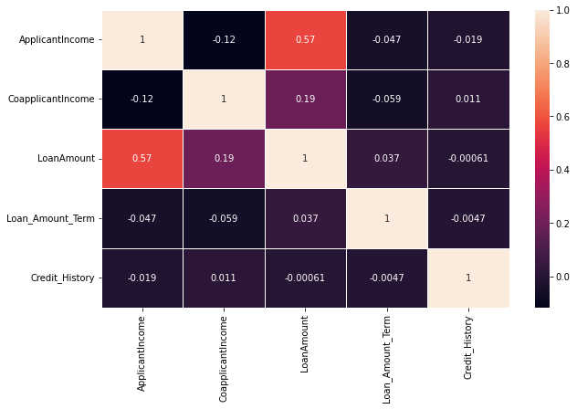

```python
plt.figure(figsize=(10,6))
sns.heatmap(df.corr(),annot=True,linewidths=1)
plt.show()
```

# Data Visualization

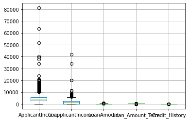

```python
df.boxplot()
```

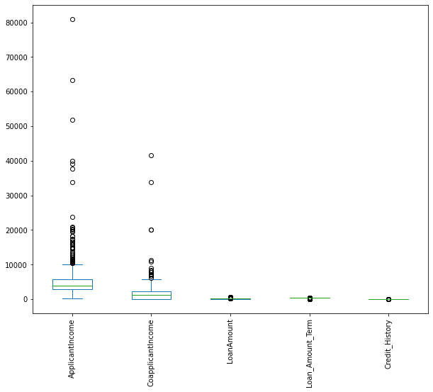

```python
df.plot(kind="box",figsize=(10,8),rot=90)
```

[output not shown]

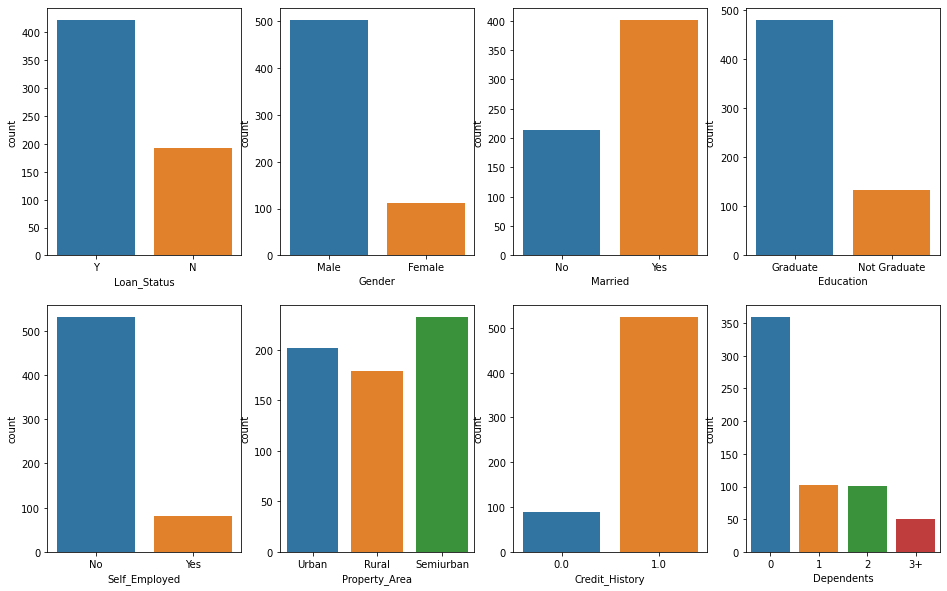

```python
fig,ax = plt.subplots(2,4,figsize=(16,10))
sns.countplot("Loan_Status",data=df,ax=ax[0][0])
sns.countplot("Gender",data=df,ax=ax[0][1])
sns.countplot("Married",data=df,ax=ax[0][2])
sns.countplot("Education",data=df,ax=ax[0][3])
sns.countplot("Self_Employed",data=df,ax=ax[1][0])
sns.countplot("Property_Area",data=df,ax=ax[1][1])
sns.countplot("Credit_History",data=df,ax=ax[1][2])
sns.countplot("Dependents",data=df,ax=ax[1][3])
```

**Conclusions from countplot** 1.From bar graph we can see that the applicants whose loan is approved has max count.

2.Applicant whos is applied for the loan is mostly of male category as compared to female category.

3.Most of the Married peoples are apply for the loan.

4.Applicants who is graduated and not self Employed are mostly apply for the loan.

5.Peoples from semiurban area are mostly apply for the loan.

6.Most of the applicants have credit history which meets the guidelines.

7.Applicant who has 0 number of dependents they generally apply for the loan.

```
array([[<AxesSubplot:title={'center':'ApplicantIncome'}>,
        <AxesSubplot:title={'center':'CoapplicantIncome'}>],
       [<AxesSubplot:title={'center':'LoanAmount'}>,
        <AxesSubplot:title={'center':'Loan_Amount_Term'}>],
       [<AxesSubplot:title={'center':'Credit_History'}>, <AxesSubplot:>]],
      dtype=object)
```

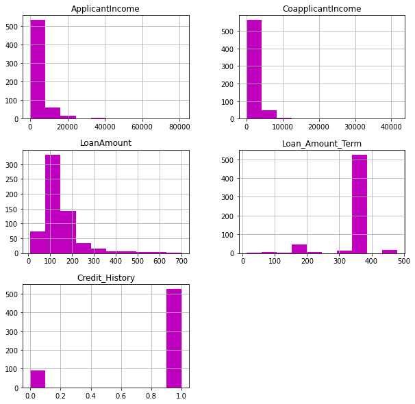

```python
df.hist(figsize=(10,10),color="m")
```

Conclusions from Histogram

From above histogram we can see that ApplicantIncome,CoapplicantIncome and LoanAmount is of positively skewed.It means the mean of these variables is greater than their median as the data is more towards the right side.

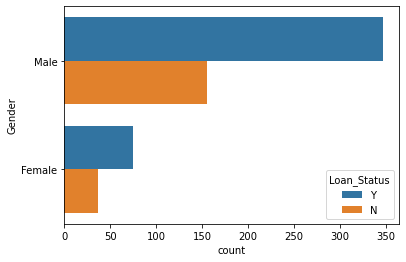

```python
sns.countplot(y="Gender",hue='Loan_Status',data=df)
```

**More males are on loan than females.Also,those that are on loan are more than otherwise**

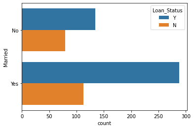

```python
sns.countplot(y="Married",hue='Loan_Status',data=df)
```

**Married people collect more loan than unmarried.**

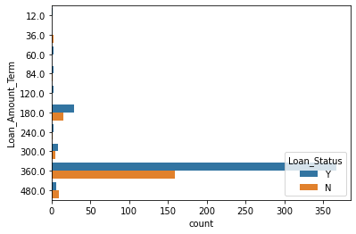

```python
sns.countplot(y="Loan_Amount_Term",hue='Loan_Status',data=df)
```

# Create new variable Income using ApplicantIncome and Co-ApplicantIncome variable as these both combinly applicant total Income

```python
df["Income"]=df.ApplicantIncome + df.CoapplicantIncome
```

```python
df.head(3)
```

|  | Loan_ID | Gender | Married | Dependents | Education | Self_Employed | ApplicantIncome | CoapplicantIncome | LoanAmount | Loan_Amount_Term | Credit_History | Property_Area | Loan_Status | Income |
| --- | --- | --- | --- | --- | --- | --- | --- | --- | --- | --- | --- | --- | --- | --- |
| 0 | LP001002 | Male | No | 0 | Graduate | No | 5849 | 0.0 | 128.0 | 360.0 | 1.0 | Urban | Y | 5849.0 |
| 1 | LP001003 | Male | Yes | 1 | Graduate | No | 4583 | 1508.0 | 128.0 | 360.0 | 1.0 | Rural | N | 6091.0 |
| 2 | LP001005 | Male | Yes | 0 | Graduate | Yes | 3000 | 0.0 | 66.0 | 360.0 | 1.0 | Urban | Y | 3000.0 |

```python
# Drop unimportant columns
df.drop(columns=["Loan_ID","ApplicantIncome","CoapplicantIncome"],inplace=True)
```

```python
df.head()
```

|  | Gender | Married | Dependents | Education | Self_Employed | LoanAmount | Loan_Amount_Term | Credit_History | Property_Area | Loan_Status | Income |
| --- | --- | --- | --- | --- | --- | --- | --- | --- | --- | --- | --- |
| 0 | Male | No | 0 | Graduate | No | 128.0 | 360.0 | 1.0 | Urban | Y | 5849.0 |
| 1 | Male | Yes | 1 | Graduate | No | 128.0 | 360.0 | 1.0 | Rural | N | 6091.0 |
| 2 | Male | Yes | 0 | Graduate | Yes | 66.0 | 360.0 | 1.0 | Urban | Y | 3000.0 |
| 3 | Male | Yes | 0 | Not Graduate | No | 120.0 | 360.0 | 1.0 | Urban | Y | 4941.0 |
| 4 | Male | No | 0 | Graduate | No | 141.0 | 360.0 | 1.0 | Urban | Y | 6000.0 |

```python
#outlier detection & removing
```

```
LoanAmount              AxesSubplot(0.125,0.71587;0.352273x0.16413)
Loan_Amount_Term     AxesSubplot(0.547727,0.71587;0.352273x0.16413)
Credit_History         AxesSubplot(0.125,0.518913;0.352273x0.16413)
Income              AxesSubplot(0.547727,0.518913;0.352273x0.16413)
dtype: object
```

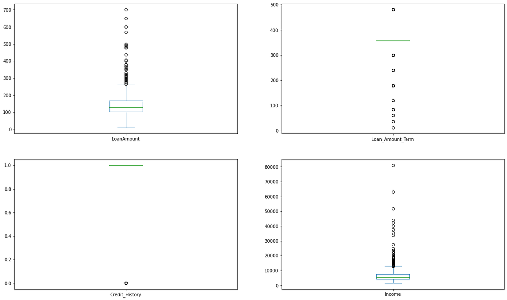

```python
df.plot(kind="box",subplots=True,layout=(4,2),sharex=False,sharey=False,figsize=(20,25))
```

```python
df = df[df.Income<10000]
df = df[df.LoanAmount<210]
```

```
LoanAmount              AxesSubplot(0.125,0.71587;0.352273x0.16413)
Loan_Amount_Term     AxesSubplot(0.547727,0.71587;0.352273x0.16413)
Credit_History         AxesSubplot(0.125,0.518913;0.352273x0.16413)
Income              AxesSubplot(0.547727,0.518913;0.352273x0.16413)
dtype: object
```

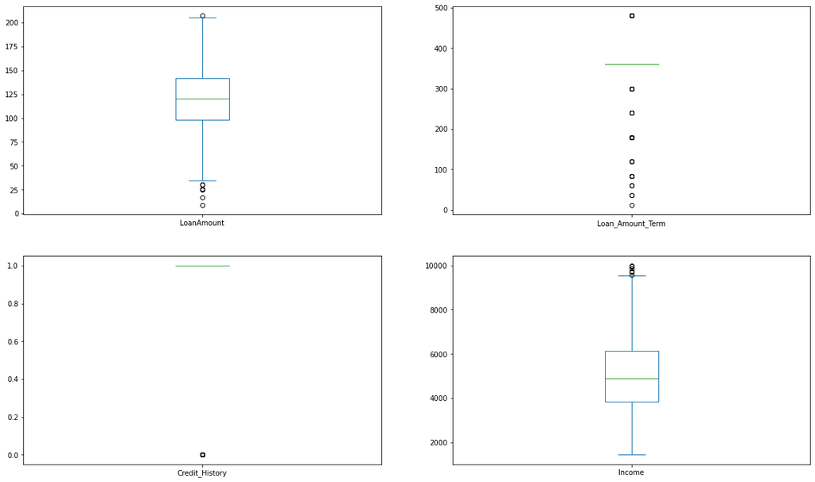

```python
df.plot(kind="box",subplots=True,layout=(4,2),sharex=False,sharey=False,figsize=(20,25))
```

```python
df.size
```

```
5489
```

```python
df.shape
```

```
(499, 11)
```

# Label Encoding

```python
from sklearn.preprocessing import LabelEncoder
```

```python
lb= LabelEncoder()
```

```python
#To create a list of character columns
lst=[]
for i in df.columns:
    if df[i].dtype=="O":
        lst.append(i)

lst
```

```
['Gender',
 'Married',
 'Dependents',
 'Education',
 'Self_Employed',
 'Property_Area',
 'Loan_Status']
```

```python
for i in lst:
    df[i]=lb.fit_transform(df[i])
```

```python
df.head()
```

|  | Gender | Married | Dependents | Education | Self_Employed | LoanAmount | Loan_Amount_Term | Credit_History | Property_Area | Loan_Status | Income |
| --- | --- | --- | --- | --- | --- | --- | --- | --- | --- | --- | --- |
| 0 | 1 | 0 | 0 | 0 | 0 | 128.0 | 360.0 | 1.0 | 2 | 1 | 5849.0 |
| 1 | 1 | 1 | 1 | 0 | 0 | 128.0 | 360.0 | 1.0 | 0 | 0 | 6091.0 |
| 2 | 1 | 1 | 0 | 0 | 1 | 66.0 | 360.0 | 1.0 | 2 | 1 | 3000.0 |
| 3 | 1 | 1 | 0 | 1 | 0 | 120.0 | 360.0 | 1.0 | 2 | 1 | 4941.0 |
| 4 | 1 | 0 | 0 | 0 | 0 | 141.0 | 360.0 | 1.0 | 2 | 1 | 6000.0 |

# Splitting Dataset

```python
x=df.drop(columns="Loan_Status")
y=df["Loan_Status"]
```

```python
x.head(n=2)
```

|  | Gender | Married | Dependents | Education | Self_Employed | LoanAmount | Loan_Amount_Term | Credit_History | Property_Area | Income |
| --- | --- | --- | --- | --- | --- | --- | --- | --- | --- | --- |
| 0 | 1 | 0 | 0 | 0 | 0 | 128.0 | 360.0 | 1.0 | 2 | 5849.0 |
| 1 | 1 | 1 | 1 | 0 | 0 | 128.0 | 360.0 | 1.0 | 0 | 6091.0 |

```python
y.head()
```

```
0    1
1    0
2    1
3    1
4    1
Name: Loan_Status, dtype: int32
```

```python
y.value_counts()
```

```
1    346
0    153
Name: Loan_Status, dtype: int64
```

As from the above count of 0 and 1 the data is not balanced, so we have to balanced it.

# Balancing dataset:

SMOTE : Synthetic Minority Oversampling Technique is a statistical technique for increasing the number of cases in the dataset in a balancing way.

```python
import imblearn
from imblearn.combine import SMOTETomek
smk = SMOTETomek(random_state = 12)
x_res,y_res =smk.fit_resample(x,y)
```

```python
x_res.shape
```

```
(594, 10)
```

```python
y_res.shape
```

```
(594,)
```

```python
from collections import Counter
```

```python
print('original dataset shape:', Counter(y))
print('Resample dataset shape', Counter(y_res))
```

```
original dataset shape: Counter({1: 346, 0: 153})
Resample dataset shape Counter({1: 297, 0: 297})
```

# Spliting into Train_Test

Now I split Data into training and Testing datasets.For this I have to import train_test_split from the sklearn.model_selection library.

```python
from sklearn.model_selection import train_test_split
X_train, X_test, y_train, y_test = train_test_split(x_res, y_res, test_size=0.3, random_state=32)
```

```python
X_train.shape,X_test.shape
```

```
((415, 10), (179, 10))
```

```python
y_train.shape,y_test.shape
```

```
((415,), (179,))
```

# Logistic Regression

```python
from sklearn.linear_model import LogisticRegression
from sklearn.metrics import accuracy_score,confusion_matrix,precision_score,recall_score
```

```python
log_m=LogisticRegression()
```

```python
log_m.fit(X_train,y_train)
```

[output not shown]

```
LogisticRegression()
```

```python
y_pred=log_m.predict(X_test)
```

```python
accuracy_score(y_test,y_pred)
```

```
0.7206703910614525
```

```python
Random_State=[]
for i in range(0,100):
    X_train, X_test, y_train, y_test = train_test_split(x, y, test_size=0.3, random_state=i)
    model=LogisticRegression()
    model.fit(X_train,y_train)
    y_pred=model.predict(X_test)
    Random_State.append(accuracy_score(y_test,y_pred))
    random_no=Random_State.index(max(Random_State))
    accuracy=max(Random_State)

maxi_iter=[]
for i in range(0,1000,50):
    X_train, X_test, y_train, y_test = train_test_split(x, y, test_size=0.3, random_state=random_no)
    model=LogisticRegression(max_iter=i)
    model.fit(X_train,y_train)
    y_pred=model.predict(X_test)
    maxi_iter.append(accuracy_score(y_test,y_pred))
    accuracy=max(Random_State)


print("Random State Number :",random_no,"Accuracy Score : ",accuracy)
print("Maximum iteration number : ",(maxi_iter.index(max(maxi_iter)))*50,"Accuracy Score : ",accuracy)
```

[output not shown]

[output cut: 513 more lines]

[output not shown]

```
Random State Number : 67 Accuracy Score :  0.9
Maximum iteration number :  100 Accuracy Score :  0.9
```

```python
precision_score(y_test,y_pred)
```

```
0.890625
```

```python
recall_score(y_test,y_pred)
```

```
0.991304347826087
```

# Decission Tree Clasifier

```python
from sklearn.tree import DecisionTreeClassifier,plot_tree
dt = DecisionTreeClassifier()
dt.fit(X_train,y_train)
y_preddt=dt.predict(X_test)
```

```python
accuracy_score(y_test,y_preddt)
```

```
0.7266666666666667
```

```python
precision_score(y_test,y_preddt)
```

```
0.8490566037735849
```

```python
recall_score(y_test,y_preddt)
```

```
0.782608695652174
```

```python
feature_name = ['Gender','Married','Dependents','Education','Self_Employed','LoanAmount','Loan_Amount_Term','Credit_History','Property_Area','Income']
```

```python
cn = ["1","0"]
```

```python
import matplotlib.pyplot as plt
%matplotlib inline
```

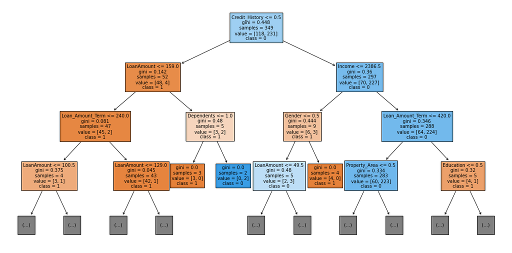

```python
plt.figure(figsize=(20,10))
a = plot_tree(dt, max_depth=3,fontsize=10,feature_names=feature_name,class_names=cn,filled=True)
plt.show()
```

```python
Random_State=[]
for i in range(0,1000):
    X_train, X_test, y_train, y_test = train_test_split(x, y, test_size=0.3, random_state=i)
    model=DecisionTreeClassifier()
    model.fit(X_train,y_train)
    y_pred=model.predict(X_test)
    Random_State.append(accuracy_score(y_test,y_pred))
    accuracy=max(Random_State)


print("Random State Number :",Random_State.index(max(Random_State)),"Accuracy Score : ",accuracy)
```

```
Random State Number : 44 Accuracy Score :  0.8333333333333334
```

# Knn Classifier

```python
from sklearn.neighbors  import KNeighborsClassifier
```

```python
model_knn = KNeighborsClassifier(n_neighbors=17)
```

```python
model_knn.fit(X_train,y_train)
```

```
KNeighborsClassifier(n_neighbors=17)
```

```python
pred = model_knn.predict(X_test)
pred
```

```
array([1, 1, 0, 1, 1, 1, 1, 1, 1, 1, 1, 1, 1, 1, 1, 1, 1, 1, 1, 1, 1, 1,
       1, 1, 1, 1, 1, 1, 1, 1, 1, 1, 1, 1, 1, 1, 1, 1, 1, 1, 0, 1, 1, 1,
       0, 1, 1, 1, 1, 1, 1, 1, 1, 1, 1, 1, 1, 1, 1, 1, 1, 1, 0, 1, 1, 1,
       1, 0, 1, 1, 1, 1, 1, 1, 1, 1, 1, 1, 1, 1, 1, 1, 1, 1, 1, 1, 1, 1,
       1, 1, 1, 1, 1, 1, 1, 1, 1, 1, 1, 1, 1, 1, 1, 1, 1, 0, 1, 1, 1, 1,
       1, 1, 1, 1, 1, 1, 1, 1, 1, 1, 1, 1, 1, 1, 1, 1, 1, 1, 1, 1, 1, 1,
       1, 1, 1, 1, 1, 1, 1, 1, 1, 1, 1, 1, 1, 1, 1, 1, 1, 1])
```

```python
accuracy_score(y_test,pred)
```

```
0.68
```

```python
precision_score(y_test,pred)
```

```
0.6875
```

```python
recall_score(y_test,pred)
```

```
0.9705882352941176
```

```python
confusion_matrix(y_test,pred)
```

```
array([[ 3, 45],
       [ 3, 99]], dtype=int64)
```

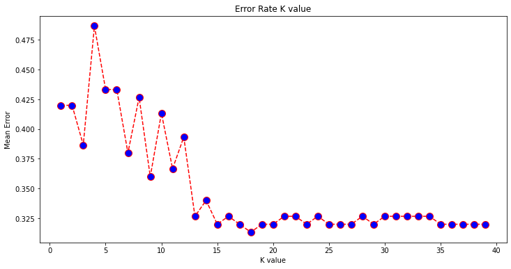

```python
error=[]
from sklearn.neighbors import KNeighborsClassifier
import matplotlib.pyplot as plt

# calculatiing error for a values between 1 and 40
for i in range(1,40):
    model = KNeighborsClassifier(n_neighbors=i)
    model.fit(X_train, y_train)
    pred=model.predict(X_test)
    error.append(np.mean(pred != y_test))

plt.figure(figsize=(12,6))
plt.plot(range(1,40),error, color='red',linestyle='dashed',marker='o',markerfacecolor='blue',markersize=10)
plt.title('Error Rate K value')
plt.xlabel("K value")
plt.ylabel("Mean Error")
```

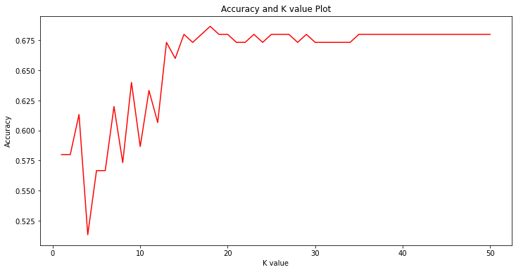

```python
accuaracy=[]
for i in range(1,51):
        model_knn=KNeighborsClassifier(n_neighbors=i)
        model_knn.fit(X_train,y_train)
        y_predknn=model_knn.predict(X_test)
        accuracy_score(y_predknn,y_test)
        accuaracy.append(accuracy_score(y_predknn,y_test))

plt.figure(figsize=(12,6))
plt.plot(range(1,51),accuaracy,color="red")
plt.title("Accuracy and K value Plot")
plt.xlabel("K value")
plt.ylabel("Accuracy")
```

# Naive_bayse classifier

```python
from sklearn.naive_bayes import GaussianNB
```

```python
model_NB = GaussianNB()
```

```python
model_NB.fit(X_train,y_train)
```

```
GaussianNB()
```

```python
pred = model_NB.predict(X_test)
pred
```

```
array([1, 1, 1, 1, 1, 1, 1, 1, 1, 1, 1, 1, 1, 1, 1, 1, 1, 1, 1, 1, 0, 0,
       1, 1, 1, 1, 1, 1, 1, 1, 1, 1, 1, 1, 1, 1, 1, 1, 1, 1, 1, 0, 1, 1,
       1, 1, 1, 1, 1, 1, 0, 1, 1, 1, 1, 1, 1, 0, 1, 0, 0, 1, 1, 0, 1, 1,
       1, 0, 1, 1, 1, 1, 1, 1, 1, 1, 1, 1, 1, 1, 1, 1, 0, 1, 1, 1, 0, 1,
       0, 1, 1, 1, 1, 1, 1, 1, 1, 1, 1, 0, 1, 1, 0, 1, 0, 1, 1, 1, 1, 1,
       1, 1, 1, 1, 1, 1, 0, 1, 1, 1, 1, 0, 1, 0, 0, 1, 0, 0, 1, 1, 1, 1,
       0, 0, 0, 0, 1, 1, 1, 1, 0, 1, 1, 1, 1, 1, 1, 1, 1, 1])
```

```python
accuracy_score(y_test,pred)
```

```
0.8133333333333334
```

```python
precision_score(y_test,pred)
```

```
0.7983870967741935
```

```python
recall_score(y_test,pred)
```

```
0.9705882352941176
```

```python
Random_State=[]
for i in range(0,100):
    X_train, X_test, y_train, y_test = train_test_split(x, y, test_size=0.3, random_state=i)
    model=GaussianNB()
    model.fit(X_train,y_train)
    y_pred=model.predict(X_test)
    Random_State.append(accuracy_score(y_test,y_pred))
    random_no=Random_State.index(max(Random_State))
    accuracy=max(Random_State)

print("Random State Number :",random_no,"Accuracy Score : ",accuracy)
```

```
Random State Number : 67 Accuracy Score :  0.8933333333333333
```

# SVM

```python
from sklearn.svm import SVC
model_sv=SVC()
```

```python
model_sv.fit(X_train,y_train)
```

```
SVC()
```

```python
y_predsv=model_sv.predict(X_test)
```

```python
accuracy_score(y_predsv,y_test)
```

```
0.7
```

```python
precision_score(y_predsv,y_test)
```

```
1.0
```

```python
recall_score(y_predsv,y_test)
```

```
0.7
```

```python
Random_State=[]
for i in range(0,100):
    X_train, X_test, y_train, y_test = train_test_split(x, y, test_size=0.3, random_state=i)
    model_sv=SVC()
    model_sv.fit(X_train,y_train)
    y_pred=model.predict(X_test)
    Random_State.append(accuracy_score(y_test,y_pred))
    random_no=Random_State.index(max(Random_State))
    accuracy=max(Random_State)

print("Random State Number :",random_no,"Accuracy Score : ",accuracy)
```

```
Random State Number : 67 Accuracy Score :  0.9
```

# Random Forest

```python
from sklearn.ensemble import RandomForestClassifier
model_rf=RandomForestClassifier()
```

```python
model_rf.fit(X_train,y_train)
```

```
RandomForestClassifier()
```

```python
RandomForestClassifier
```

```
sklearn.ensemble._forest.RandomForestClassifier
```

```python
RandomForestClassifier()
```

```
RandomForestClassifier()
```

```python
y_predrf=model_rf.predict(X_test)
```

```python
accuracy_score(y_predrf,y_test)
```

```
0.8
```

```python
precision_score(y_predrf,y_test)
```

```
0.9238095238095239
```

```python
recall_score(y_predrf,y_test)
```

```
0.8151260504201681
```

```python
# Random_State=[]
for i in range(0,100):
    X_train, X_test, y_train, y_test = train_test_split(x, y, test_size=0.3, random_state=i)
    model_rf=RandomForestClassifier()
    model_rf.fit(X_train,y_train)
    y_pred=model.predict(X_test)
    Random_State.append(accuracy_score(y_test,y_pred))
    random_no=Random_State.index(max(Random_State))
    accuracy=max(Random_State)

print("Random State Number :",random_no,"Accuracy Score : ",accuracy)
```

```
Random State Number : 67 Accuracy Score :  0.9
```

# Gradient Boosting

```python
from sklearn.ensemble import GradientBoostingClassifier
md=GradientBoostingClassifier()
```

```python
md.fit(X_train,y_train)
```

```
GradientBoostingClassifier()
```

```python
y_predgb=md.predict(X_test)
y_predgb
```

```
array([1, 1, 1, 1, 1, 1, 0, 0, 1, 1, 1, 1, 1, 1, 0, 0, 1, 1, 1, 1, 1, 1,
       1, 0, 1, 0, 1, 1, 1, 1, 0, 1, 1, 1, 0, 1, 0, 1, 0, 1, 1, 1, 1, 0,
       1, 0, 0, 1, 1, 1, 0, 1, 1, 0, 1, 1, 1, 1, 1, 1, 0, 0, 1, 1, 1, 1,
       1, 1, 1, 0, 1, 0, 1, 1, 1, 1, 0, 1, 0, 1, 0, 1, 1, 1, 1, 1, 1, 1,
       0, 1, 0, 1, 0, 0, 1, 1, 1, 1, 1, 1, 0, 1, 1, 1, 1, 1, 1, 1, 1, 1,
       1, 1, 0, 1, 1, 1, 1, 1, 1, 1, 0, 1, 1, 1, 1, 1, 1, 1, 1, 0, 0, 1,
       1, 1, 1, 1, 1, 1, 1, 1, 0, 0, 0, 1, 1, 1, 1, 1, 1, 1])
```

```python
accuracy_score(y_predgb,y_test)
```

```
0.78
```

```python
precision_score(y_predgb,y_test)
```

```
0.8952380952380953
```

```python
recall_score(y_predgb,y_test)
```

```
0.8103448275862069
```

```python
Random_State=[]
for i in range(0,100):
    X_train, X_test, y_train, y_test = train_test_split(x, y, test_size=0.3, random_state=i)
    md=GradientBoostingClassifier()
    md.fit(X_train,y_train)
    y_pred=md.predict(X_test)
    Random_State.append(accuracy_score(y_test,y_pred))
    random_no=Random_State.index(max(Random_State))
    accuracy=max(Random_State)

print("Random State Number :",random_no,"Accuracy Score : ",accuracy)
```

```
Random State Number : 30 Accuracy Score :  0.8666666666666667
```

# Accuracy , precision and Recall:

1) Logistic regression: Accuracy:0.7206703910614525 Precision:0.890625 Recall:0.991304347826087

3)Knn : Accuracy:0.68 Precision:0.6875 Recall:0.9705882352941176

4) Neive Bayes: Accuracy:0.8133333333333334 Precision:0.7983870967741935 Recall:0.9705882352941176

5) SVM: Accuracy:0.7 Precision:1.0 Recall:0.7

```python
Loan_ID=int(input("ENTER THE LOAN_ID:"))
Gender=int(input("ENTER THE gender:"))
Married=int(input("ENTER THE APPLICANT MARRIED:"))
Dependents=int(input("ENTER THE Number of dependents:"))
Education=int(input("ENTER THE Applicant Education:"))
Self_Employed=int(input("ENTER THE Self employed:"))
ApplicantIncome=int(input("ENTER THE Applicant income :"))
CoapplicantIncome=int(input("enter Coapplicant income:"))
LoanAmount=int(input("ENTER THE Loan amount in thousands:"))
Loan_Amount_Term =float(input("ENTER THE Term of loan in months:"))
Credit_History=int(input("ENTER THE credit history meets guidelines:"))
Property_Area=int(input("ENTER THE Urban:"))
Loan_Status=int(input("ENTER THE Loan approved:"))


pred=model.predict([[Gender, Married, Dependents, Education, Self_Employed,
       LoanAmount, Loan_Amount_Term, Credit_History, Property_Area,
       Loan_Status]])
print(pred)

if(pred==0):
    print("Loan is approved")
else:
    print("not approved")
```

```
ENTER THE LOAN_ID:6
ENTER THE gender:8
ENTER THE APPLICANT MARRIED:56
ENTER THE Number of dependents:23
ENTER THE Applicant Education:34
ENTER THE Self employed:45
ENTER THE Applicant income :67
enter Coapplicant income:89
ENTER THE Loan amount in thousands:456
ENTER THE Term of loan in months:65
ENTER THE credit history meets guidelines:8
ENTER THE Urban:76
ENTER THE Loan approved:6
[0]
Loan is approved
```

```
C:\Users\admin\anaconda3\14-09-2022 anaconda\lib\site-packages\sklearn\base.py:450: UserWarning: X does not have valid feature names, but GaussianNB was fitted with feature names
  warnings.warn(
```

```python
def df(Gender, Married, Dependents, Education, Self_Employed,
       LoanAmount, Loan_Amount_Term, Credit_History, Property_Area,
       Loan_Status):
    pred=model.predict([[Gender, Married, Dependents, Education, Self_Employed,
       LoanAmount, Loan_Amount_Term, Credit_History, Property_Area,
       Loan_Status]])
    print(pred)

    if(pred==0):
        print("Loan is approved")
    else:
        print("not approved")
```

```python
df(67,8,438,479,3847,374,3,32,453,87)
```

```
[1]
not approved
```

```
C:\Users\admin\anaconda3\14-09-2022 anaconda\lib\site-packages\sklearn\base.py:450: UserWarning: X does not have valid feature names, but GaussianNB was fitted with feature names
  warnings.warn(
```